# Camera trap distance sampling workshop

Practical 4 solution:  
model selection with overdispersed data

Workshop development group https://workshops.distancesampling.org (CREEM, Univ of St Andrews)https://www.creem.st-andrews.ac.uk  
2022-03-28

# Model selection adjustments from overdispersion

Overdispersion causes AIC to select overly-complex models, so analysts should specify the number/order of adjustment terms manually when fitting distance sampling models to data from camera traps, rather than allowing automated selection using AIC. Howe, Buckland, Després-Einspenner, & Kühl (2019) describes two methods for performing model selection of distance sampling models in the face of overdispersion. Here we provide R functions to perform the first of these methods. The first method of Howe et al. (2019) employs a two-step process. First, an overdisersion factor $(\hat{c})$ is computed for each key function family from the most complex model in each family. The $\hat{c}$ is derived from the $\chi^2$ goodness of fit test statistic divided by its degrees of freedom. This results in an adjusted AIC score for each model in the key function family:

$$QAIC = -2 \left \{
\frac{log(\mathcal{L}(\hat{\theta}))}{\hat{c}} \right \} +
2K$$

Code to perform this QAIC computation is found in the function `QAIC` in the `Distance` R package.

# Re-acquire previously fitted models

Load the `Distance` package, the previously fitted models and the flat file of peak activity duiker data.

```r
library(Distance)
data("DuikerCameraTraps")
load("duikermodels.RData")
```

# Compute QAIC for each set of key function models

Apply the functions defined to compute QAIC values for the half normal, uniform and hazard rate key function models.

```r
hnQAIC <- QAIC(hn0, hn1, hn2)
uniQAIC <- QAIC(uni1, uni2)
hrQAIC <- QAIC(hr0, hr1, hr2)
```

Tables of QAIC values for each key function family are shown below (code for `kable()` calls suppressed for easier readability of results).

Table 1: QAIC values for half normal key models.

|  | df | QAIC |
| --- | --- | --- |
| hn0 | 1 | 1132.719 |
| hn1 | 2 | 1128.462 |
| hn2 | 3 | 1130.438 |

Table 2: QAIC values for uniform key models.

|  | df | QAIC |
| --- | --- | --- |
| uni1 | 1 | 944.6180 |
| uni2 | 2 | 946.4803 |

Table 3: QAIC values for hazard rate key models.

|  | df | QAIC |
| --- | --- | --- |
| hr0 | 2 | 2013.81 |
| hr1 | 3 | 2015.81 |
| hr2 | 4 | 2017.81 |

From this first pass of model selection based on QAIC values, we find the preferable model with the hazard rate key function is one without adjustment terms. The model with the uniform key function preferred by QAIC has a single adjustment term; likewise for the half normal key function.

The second step of model selection ranks the models by their $\hat{c}$ values.

```r
chats <- chi2_select(hn1, uni1, hr0)
modnames <- unlist(lapply(list(hn1, uni1, hr0), function(x) x$ddf$name.message))
results <- data.frame(modnames, chats)
results.sort <- results[order(results$criteria),]
knitr::kable(results.sort, digits=2, row.names = FALSE,
             caption="Compare with Table S5 of Howe et al. (2018)")
```

Table 4: Compare with Table S5 of Howe et al. (2018)

| modnames | criteria |
| --- | --- |
| hazard-rate key function | 8.26 |
| half-normal key function with Hermite(4) adjustments | 18.60 |
| uniform key function with cosine(1) adjustments | 23.22 |

For this data set, the model chosen by this algorithm that adjusts for overdispersion is the same model (hazard rate key without adjustments) as would have been chosen by conventional model selection.

# Sensibility check for detection parameter estimates

As a check of the detection function vis-a-vis Howe, Buckland, Després-Einspenner, & Kühl (2017), the paper reports the effective detection radius ($\rho$) to be 9.4m for the peak activity data set.

The effective detection radius can be derived from $\hat{P_a}$ as reported by the function `ds` as

$$\hat{\rho} = \sqrt{\hat{P_a} \cdot
w^2}$$

```r
p_a <- hr0$ddf$fitted[1]
w <- 15
rho <- sqrt(p_a * w^2)
```

$\hat{P_a}$ is estimated to be 0.398, resulting in an estimate of $\hat{\rho}$ of 9.462.

# Selected detection function

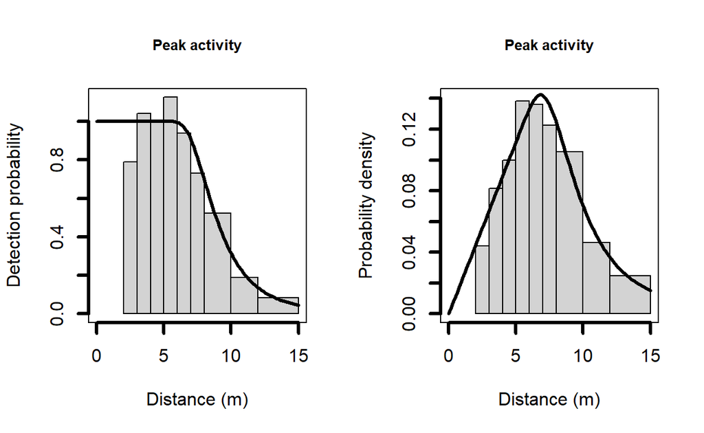

```r
par(mfrow=c(1,2))
plot(hr0, main="Peak activity", xlab="Distance (m)",
     showpoints=FALSE, lwd=3, xlim=c(0, 15))
plot(hr0, main="Peak activity", xlab="Distance (m)", pdf=TRUE,
     showpoints=FALSE, lwd=3, xlim=c(0, 15))
```

## Density estimates

The camera traps do not view the entire area around them, as would be the case with simple point transect sampling. The portion of the area sampled needs to be incorporated in the estimation of abundance. The data file contains a column `multiplier` that represents the proportion of the circle sampled. Howe et al. (2017) notes the camera angle of view (AOV) of 42$^{\circ}$. The proportion of the circle viewed is this value over 360$^{\circ}$.

An argument to `dht2` is `sample_fraction`, an obvious place to include this quantity.

```r
viewangle <- 42 # degrees
samfrac <- viewangle / 360
conversion <- convert_units("meter", NULL, "square kilometer")
peak.hr.dens <- dht2(hr0, flatfile=DuikerCameraTraps, strat_formula = ~1,
                     sample_fraction = samfrac, er_est = "P2", convert_units = conversion)
print(peak.hr.dens, report="density")
```

```
Density estimates from distance sampling
Stratification : geographical
Variance       : P2, n/L
Multipliers    : none
Sample fraction : 0.1166667


Summary statistics:
 .Label  Area CoveredArea   Effort    n  k ER se.ER cv.ER
  Total 40.37    1015.748 12317058 5865 21  0     0 0.302

Density estimates:
 .Label Estimate    se    cv    LCI     UCI     df
  Total  14.5106 4.384 0.302 7.8351 26.8734 20.094

Component percentages of variance:
 .Label Detection    ER
  Total      0.23 99.77
```

The density estimate uses detections from only a portion of the day (termed “peak activity” in Howe et al. (2017)). In the next practical, we examine activity patterns from the camera data to adjust density estimates for daily periods of inactivity when cameras will not trigger.

# Questions

- Explain the printed encounter rate and its standard error
  - The units of measure for camera trapping designs is the number of detections per snapshot duration. In this study, the snapshot was 2 second in duration. Hence the number of detections in that time interval is very small. Both the encounter rate and its standard error are non-zero because the CV is reported as ~0.30. Nevertheless, it is important to scrutinise output from all aspects of the analysis, looking for possible errors; however, there is no error in this instance.
- Explain the `Component percentages of variance` table at the end of the `dht2` output
  - Essentially all uncertainty in the density estimate is attributable to variability in the number of detections between camera stations.
  - should this be a cause for concern?
    - Somewhat. Uncertainty in the shape of the detection function plays virtually no role in the density estimate.
  - if it is a cause for concern, what remedy can be employed?
    - After the data have been collected, there is little that can be done to effect a remedy. At the survey design phase of the study, a larger number of detection stations should be employed. In addition, geographic stratification; identifying high density and low density regions in the study area, deploying camera in each strata. Stratification is the statistical technique used to increase precision in estimates.

Howe, E. J., Buckland, S. T., Després-Einspenner, M.-L., & Kühl, H. S. (2017). Distance sampling with camera traps. *Methods in Ecology and Evolution*, *8*(11), 1558–1565. https://doi.org/10.1111/2041-210X.12790

Howe, E. J., Buckland, S. T., Després-Einspenner, M.-L., & Kühl, H. S. (2019). Model selection with overdispersed distance sampling data. *Methods in Ecology and Evolution*, *10*(1), 38–47. https://doi.org/10.1111/2041-210X.13082